# Genome-wide methylation analysis report

# Genome-wide methylation analysis report

- study: Pleural cfDNAm analysis of ph.platevariable
- author: Paul Yousefi
- date: 08 October, 2026

## Parameters

```
## $sig.threshold
## [1] 2.121143e-07
##
## $max.plots
## [1] 10
##
## $qq.inflation.method
## [1] "median"
##
## $practical.threshold
## [1] 0.0001898926
```

## Sample characteristics

For continuous or ordinal variables, the “mean” column provides the mean and the “sd/%” column the standard deviation of the variable. For categorical variables, the “mean” column provides the number of samples with the given “value” and the “sd/%” column the percentage of samples with the given “value”.

| variable | value | mean | sd.. |
| --- | --- | --- | --- |
| ph |  | 7.443586 | 0.1814192 |
| plate |  | 2.324895 | 1.045538 |
| sv1 |  | 1.051893e-18 | 0.06509446 |
| sv2 |  | 1.071765e-18 | 0.06509446 |
| sv3 |  | -1.020643e-18 | 0.06509446 |
| sv4 |  | 2.051321e-19 | 0.06509446 |
| sv5 |  | -3.111377e-18 | 0.06509446 |
| sv6 |  | -4.208889e-18 | 0.06509446 |
| sv7 |  | -6.589273e-19 | 0.06509446 |
| sv8 |  | 1.535381e-20 | 0.06509446 |
| sv9 |  | -1.22612e-17 | 0.06509446 |
| sv10 |  | 9.251092e-16 | 0.06509446 |

## Covariate associations

### Covariate plate

statistics

| var1 | var2 | F | p-value | R | p-value |
| --- | --- | --- | --- | --- | --- |
| ph | plate | 0.123554 | 0.7255264 | 0.0562252 | 0.3888625 |

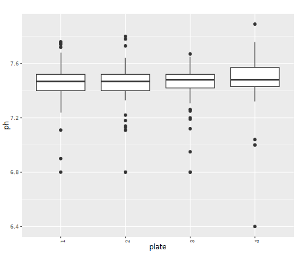

### Covariate sv1

statistics

| var1 | var2 | F | p-value | R | p-value |
| --- | --- | --- | --- | --- | --- |
| ph | sv1 | 0.2727099 | 0.6020116 | 0.0332371 | 0.6106726 |

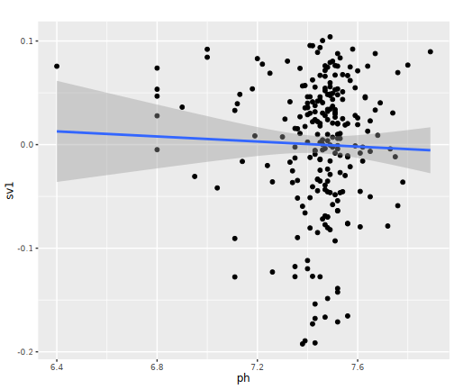

### Covariate sv2

statistics

| var1 | var2 | F | p-value | R | p-value |
| --- | --- | --- | --- | --- | --- |
| ph | sv2 | 0.6095614 | 0.4357387 | 0.0720529 | 0.269241 |

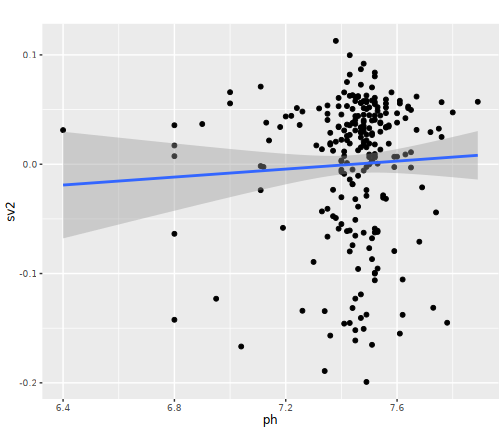

### Covariate sv3

statistics

| var1 | var2 | F | p-value | R | p-value |
| --- | --- | --- | --- | --- | --- |
| ph | sv3 | 2.627232 | 0.1063857 | 0.1730089 | 0.007596 |

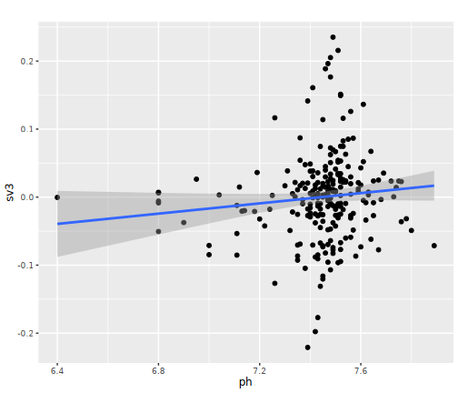

### Covariate sv4

statistics

| var1 | var2 | F | p-value | R | p-value |
| --- | --- | --- | --- | --- | --- |
| ph | sv4 | 0.354016 | 0.552421 | -0.0626418 | 0.3369534 |

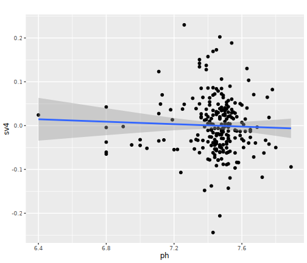

### Covariate sv5

statistics

| var1 | var2 | F | p-value | R | p-value |
| --- | --- | --- | --- | --- | --- |
| ph | sv5 | 0.0340268 | 0.853809 | 0.0197744 | 0.7620098 |

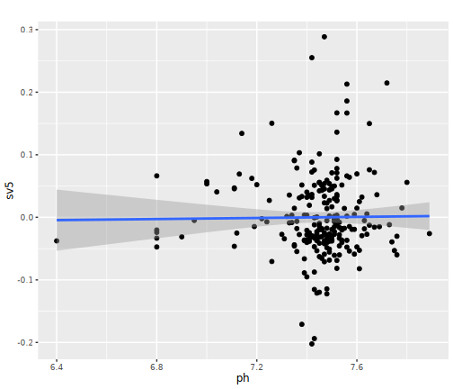

### Covariate sv6

statistics

| var1 | var2 | F | p-value | R | p-value |
| --- | --- | --- | --- | --- | --- |
| ph | sv6 | 0.0794351 | 0.7783125 | 0.0197699 | 0.7620624 |

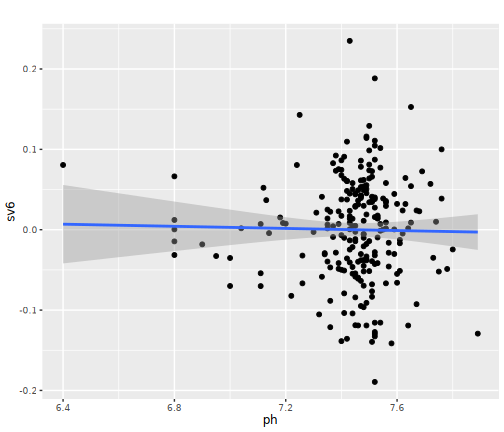

### Covariate sv7

statistics

| var1 | var2 | F | p-value | R | p-value |
| --- | --- | --- | --- | --- | --- |
| ph | sv7 | 0.0018385 | 0.9658356 | 0.0096678 | 0.8823034 |

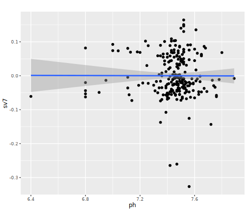

### Covariate sv8

statistics

| var1 | var2 | F | p-value | R | p-value |
| --- | --- | --- | --- | --- | --- |
| ph | sv8 | 0.0258866 | 0.8723159 | -0.057151 | 0.3810886 |

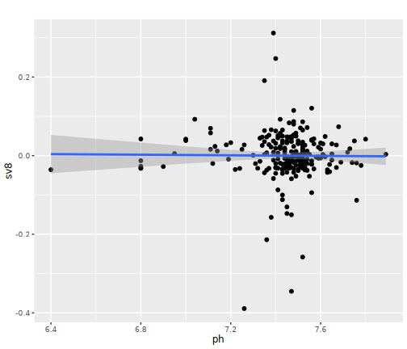

### Covariate sv9

statistics

| var1 | var2 | F | p-value | R | p-value |
| --- | --- | --- | --- | --- | --- |
| ph | sv9 | 0.0667833 | 0.7963053 | 0.0087675 | 0.8931946 |

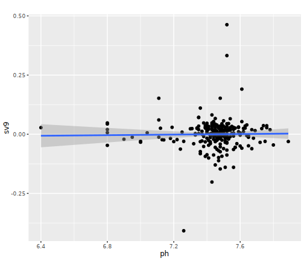

### Covariate sv10

statistics

| var1 | var2 | F | p-value | R | p-value |
| --- | --- | --- | --- | --- | --- |
| ph | sv10 | 0.0103368 | 0.9191052 | 0.0277273 | 0.6710688 |

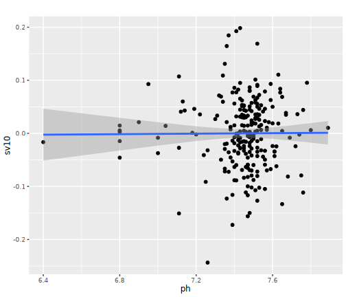

## QQ plots

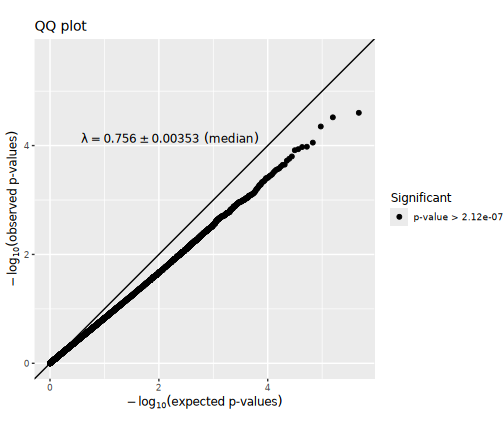

## Manhattan plots

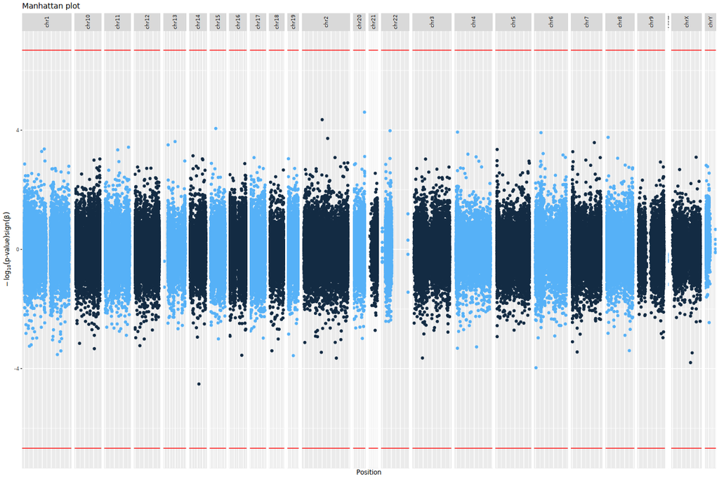

## Significant CpG sites

There were 0 CpG sites with association p-values < 2.1211427 × 10<sup>-7</sup>. These are listed in the file associations.csv.

Below are the 10 CpG sites with association p-values < 1.8989259 × 10<sup>-4</sup> in the regression model.

|  | chromosome | position | estimate | p.value | p.adjust |
| --- | --- | --- | --- | --- | --- |
| cg26401018 | chr22 | 42971631 | 0.0817058 | 0.0001050 | 1 |
| cg25535698 | chr20 | 60800277 | 0.1250527 | 0.0000250 | 1 |
| cg02705759 | chr4 | 7283005 | 0.1391367 | 0.0001165 | 1 |
| cg20374349 | chr15 | 50541593 | 0.1526570 | 0.0000882 | 1 |
| cg03213487 | chr2 | 100404536 | 0.1247624 | 0.0000446 | 1 |
| cg27361814 | chrX | 100074568 | -0.2090119 | 0.0001584 | 1 |
| cg19637866 | chr14 | 69106301 | -0.1315012 | 0.0000303 | 1 |
| cg09351698 | chr6 | 30453713 | 0.1913156 | 0.0001218 | 1 |
| cg05328264 | chr8 | 8457005 | 0.0769766 | 0.0001747 | 1 |
| cg26893685 | chr6 | 2523615 | -0.1727512 | 0.0001063 | 1 |

Plots of these sites follow, one for each covariate set. “p[lm]” denotes the p-value obtained using a linear model and “p[beta]” the p-value obtained using beta regression.

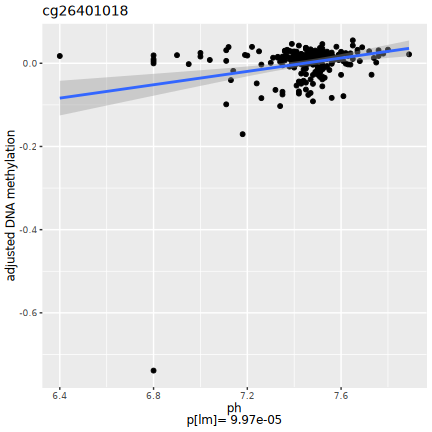

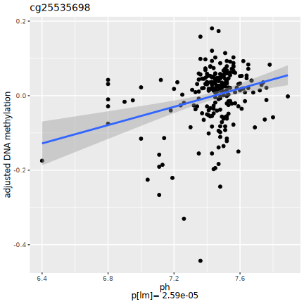

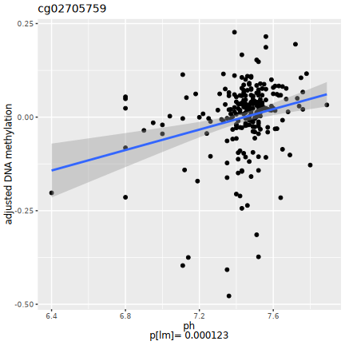

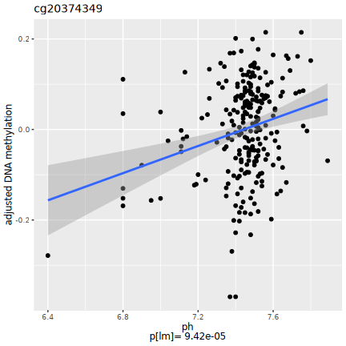

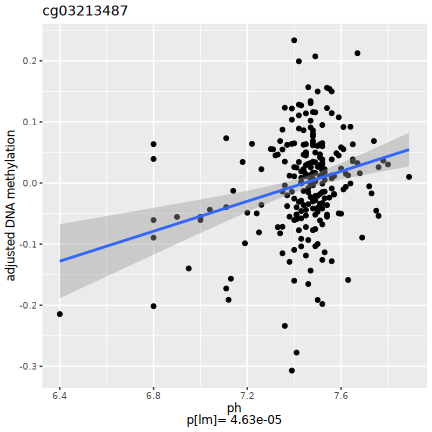

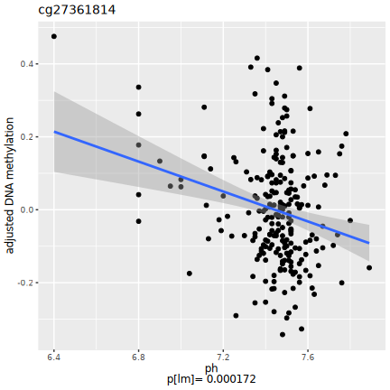

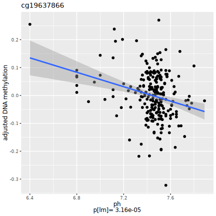

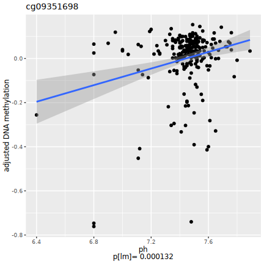

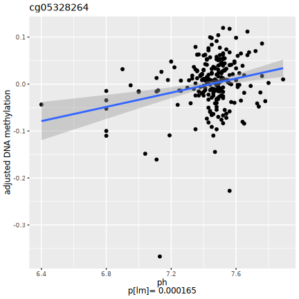

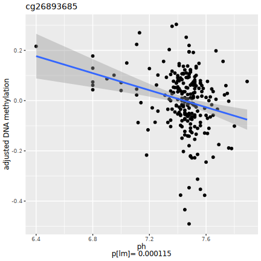

## Selected CpG sites

Number of CpG sites selected: 0.

| chromosome | position | estimate | p.value | p.adjust |
| --- | --- | --- | --- | --- |